# First project John Hopkins

Akanksha

2/22/2022

Lets begin with step 1 and read the data here.

```r
df <- read.csv("activity.csv" , header = TRUE)
##Taking a sneak peak inside data to make sure its read correctly.
head(df)
```

```
##   steps       date interval
## 1    NA 2012-10-01        0
## 2    NA 2012-10-01        5
## 3    NA 2012-10-01       10
## 4    NA 2012-10-01       15
## 5    NA 2012-10-01       20
## 6    NA 2012-10-01       25
```

For a better understanding of data, we can see its glimpse using the glimpse function. we would need to load Tidyverse package in order to use this fucntion

```r
library(tidyverse)
glimpse(df)
```

```
## Rows: 17,568
## Columns: 3
## $ steps    <int> NA, NA, NA, NA, NA, NA, NA, NA, NA, NA, NA, NA, NA, NA, NA, N~
## $ date     <chr> "2012-10-01", "2012-10-01", "2012-10-01", "2012-10-01", "2012~
## $ interval <int> 0, 5, 10, 15, 20, 25, 30, 35, 40, 45, 50, 55, 100, 105, 110, ~
```

we notice that date column of the dataset is “character” type. we need to change this using lubridate package and converting it into date type.

```r
library(lubridate)
df$date <- ymd(df$date)
```

To begin with the code for step 2 , plotting Histogram of total number of steps taken each day , we first need to calculate the total steps for each day.

```r
histdf <- df%>%group_by(date)%>%summarise("total_steps" = sum(steps))
head(histdf)
```

```
## # A tibble: 6 x 2
##   date       total_steps
##   <date>           <int>
## 1 2012-10-01          NA
## 2 2012-10-02         126
## 3 2012-10-03       11352
## 4 2012-10-04       12116
## 5 2012-10-05       13294
## 6 2012-10-06       15420
```

Here we get a tibble object displaying the summarised data where each date is followed by a column stating the total steps taken on that day. Now we will proceed with the histogram.

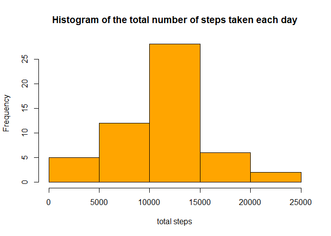

```r
hist(histdf$total_steps, xlab = "total steps", main = "Histogram of the total number of steps taken each day" , col = "orange")
```

For step 3, we can use Tidyverse package to summarise data in terms of mean and median.

```r
dfstep3 <- df%>%group_by(date)%>%summarise("mean_steps" = mean(steps)
                                           ,"median_steps" = median(steps))
head(dfstep3)
```

```
## # A tibble: 6 x 3
##   date       mean_steps median_steps
##   <date>          <dbl>        <dbl>
## 1 2012-10-01     NA               NA
## 2 2012-10-02      0.438            0
## 3 2012-10-03     39.4              0
## 4 2012-10-04     42.1              0
## 5 2012-10-05     46.2              0
## 6 2012-10-06     53.5              0
```

```r
dfstep4 <- df%>%group_by(interval,date)%>%summarise("avgsteps" = mean(steps))
```

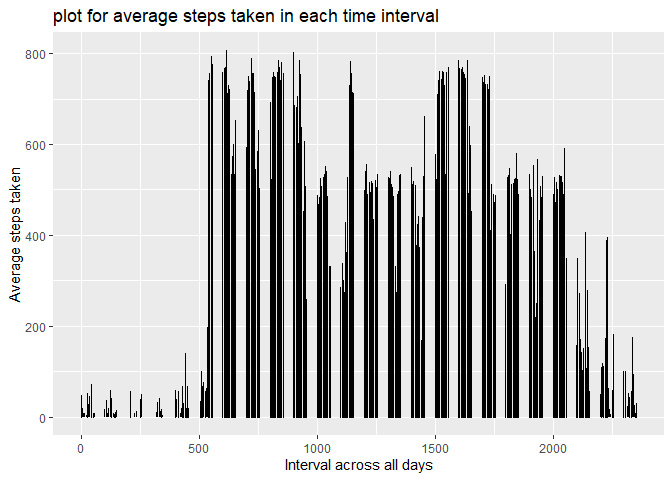

```r
library(ggplot2)
dfstep4%>%ggplot(mapping = aes( x = interval,  y = avgsteps))+
  geom_line()+
  labs( x = "Interval across all days", y = "Average steps taken",title =       "plot for average steps taken in each time interval")
```

to get the interval containing maximum number of steps, we can make use of above tibble and calculate max

```r
dfstep4[which.max(dfstep4$avgsteps),]
```

```
## # A tibble: 1 x 3
## # Groups:   interval [1]
##   interval date       avgsteps
##      <int> <date>        <dbl>
## 1      615 2012-11-27      806
```

Now for the next task, we first need to report the total number of missing values in the dataset

```r
nrow(df[!complete.cases(df),])
```

```
## [1] 2304
```

we will now devise a strategy to fill all of the NA values and replace it with 0 instead.

```r
 df$steps <- df$steps%>%replace_na("0")
```

Now we have a new dataset where all the missing values i.e NA is now replaced with zero. For the next step of assignment , we will see if this brings any change to the plots we earlier made.

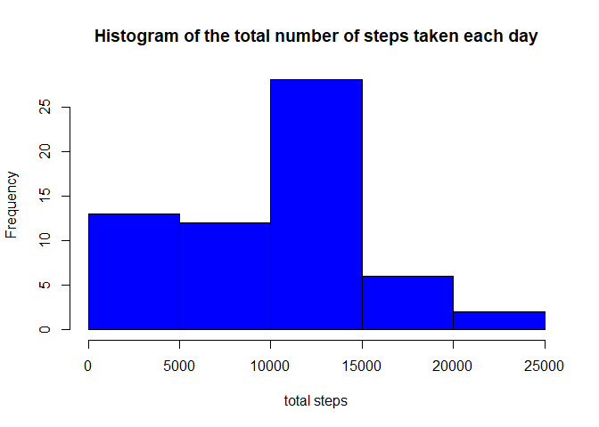

```r
df$steps <- as.numeric(df$steps)
histdf <- df%>%group_by(date)%>%summarise("total_steps"=(sum(steps)))
hist(histdf$total_steps, xlab = "total steps", main = "Histogram of the total number of steps taken each day" , col = "blue")
```

```r
dfstep7 <- df%>%group_by(date)%>%summarise("mean_steps" = mean(steps)
                                           ,"median_steps" = median(steps))
head(dfstep7)
```

```
## # A tibble: 6 x 3
##   date       mean_steps median_steps
##   <date>          <dbl>        <dbl>
## 1 2012-10-01      0                0
## 2 2012-10-02      0.438            0
## 3 2012-10-03     39.4              0
## 4 2012-10-04     42.1              0
## 5 2012-10-05     46.2              0
## 6 2012-10-06     53.5              0
```

Now here we go for the next task that is to create new factor variable with two levels “weekdays” and “weekend”

```r
df$date <-  as.POSIXct(df$date, format = "%Y-%m-%d")
df <- df%>%mutate("Day_of_week" =  weekdays(date))
df$Day_of_week <- recode("Monday" = "weekday","Tuesday"="weekday","Wednesday"="weekday","Thursday"="weekday",
                         "Friday" = "weekday","Saturday"="weekend",
                         "Sunday"="weekend",df$Day_of_week)

df$Day_of_week <- as.factor(df$Day_of_week)
head(df, 10)
```

```
##    steps                date interval Day_of_week
## 1      0 2012-10-01 05:30:00        0     weekday
## 2      0 2012-10-01 05:30:00        5     weekday
## 3      0 2012-10-01 05:30:00       10     weekday
## 4      0 2012-10-01 05:30:00       15     weekday
## 5      0 2012-10-01 05:30:00       20     weekday
## 6      0 2012-10-01 05:30:00       25     weekday
## 7      0 2012-10-01 05:30:00       30     weekday
## 8      0 2012-10-01 05:30:00       35     weekday
## 9      0 2012-10-01 05:30:00       40     weekday
## 10     0 2012-10-01 05:30:00       45     weekday
```